# Fifa 19: Exploratory Analysis on Wage Distributions

##### Learning Objectives

1. Cleaning up data
2. Exploring data through plots
3. Conducting Hypothesis tests between 2 populations

**Load libraries**  
Main libraries: `ggplot2`, `tidyverse`, `dplyr`, `gridExtra`, `stringr`.

**Load data**  
From Kaggle datasets: FIFA 19  
Link: https://www.kaggle.com/karangadiya/fifa19

```
## [1] "Original size: " "18207 x 89"
```

#### Section 1. Clean up data

##### 1.1 | — Check for NaN and players without Clubs

Checking for NaN entries, in which case, those rows are removed. Additionally, there are players without a current club, as such their Wage and Value are 0. The corresponding rows to those players are also removed.

```r
df <- na.omit(df)
df <- df[-which(df$Club == ''),]
```

##### 1.2 | — Narrow down selected columns

From the full dataset, select the following variables: `ID`, `Name`, `Age`, `Nationality`, `Overall`, `Potential`, `Club`, `Value`, `Wage`, `Preferred.Foot`, `International.Reputation`, `Position`, `Jersey.Number`, `Height`, `Weight`, `Release.Clause`.

Also convert:

1. `Overall`, `Potential` from interger to numeric.
2. `Club` from character to factor.

```
## [1] "Current size: " "17918 x 16"
```

##### 1.3 | — Reformat ‘Value’, ‘Wage’, ‘Release Clause’

When read into R, the character for Euro sign is not properly displayed, for example:

```
##       Value    Wage Release.Clause
## 1 â¬110.5M â¬565K      â¬226.5M
```

**Reformat:** All monetary units in the data is Euro.

```
##       Value   Wage Release.Clause
## 1 110500000 565000      226500000
```

##### 1.4 | — Reclassify positions

There are over 20 positions in the original dataset, for example:

```
##  [1] RF  ST  LW  GK  RCM LF  RS  RCB LCM CB  LDM CAM CDM LS  LCB RM  LAM
## [18] LM  LB  RDM RW  CM  RB  RAM CF  RWB LWB
## 28 Levels:  CAM CB CDM CF CM GK LAM LB LCB LCM LDM LF LM LS LW LWB ... ST
```

**Reclassify into:**

1. `Position_2` simpler positions
2. `Position_Horizontal` GK - Center - Wing
3. `Position_Vertical` GK - Defense - Midfield - Attack

```
##  [1] ST  LW  GK  CB  CM  LB  LM  RM  RB  RW  LWB RWB
## Levels: CB CM GK LB LM LW LWB RB RM RW RWB ST
```

```
## [1] Center Wing   GK
## Levels: Center GK Wing
```

```
## [1] Attack   GK       Defense  Midfield
## Levels: Attack Defense GK Midfield
```

##### 1.5 | — Rename club names

Like for ‘Wage’ above, when read into R, special characters are not properly displayed, for example:

```
## [1] AtlÃ©tico Madrid   FC Bayern MÃ¼nchen
## 652 Levels:   SSV Jahn Regensburg 1. FC Heidenheim 1846 ... ZagÅÄ\231bie Sosnowiec
```

Rename clubs from top 5 leagues: `Serie A`, `EPL`, `La Liga`, `Bundesliga`, `Ligue 1`

```
## [1] "Atletico Madrid"   "FC Bayern Munchen"
```

##### 1.6 | — Label league for top 5 leagues

`Serie A`, `EPL`, `La Liga`, `Bundesliga`, `Ligue 1`

```
## [1] La Liga   Serie A   Ligue 1   EPL       Bundesiga <NA>
## Levels: Bundesiga EPL La Liga Ligue 1 Serie A
```

#### Section 2: Plots

##### 2.1 | — Wage against Overall and Vertical Positions

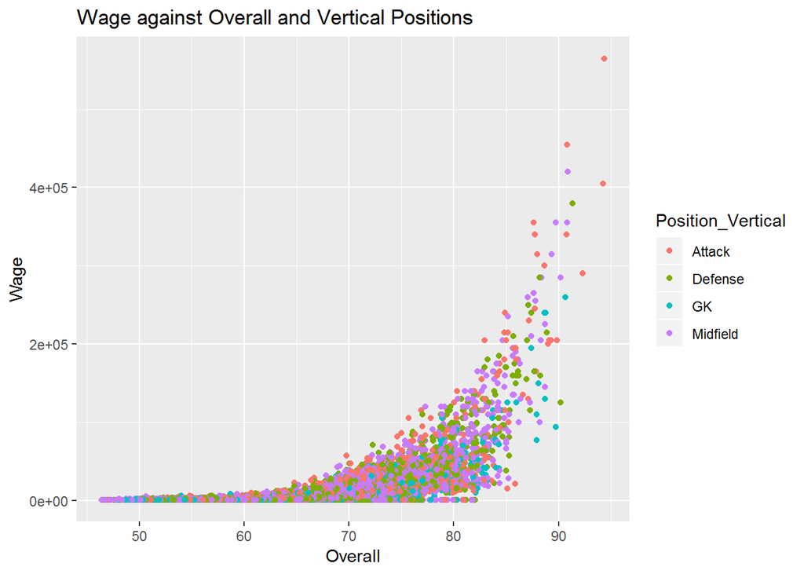

##### 2.2 | — Wage vs. Vertical Positions

Boxplot: Wage against Vertical Positions for each of top 5 leagues + rest

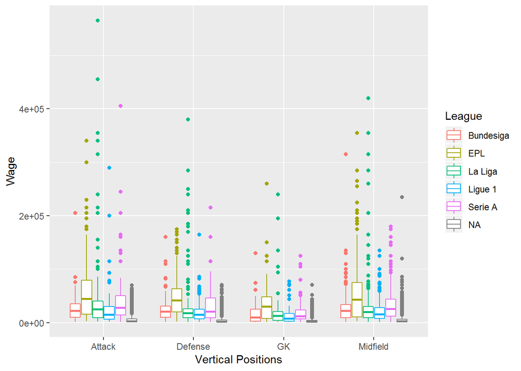

##### 2.3 | — Wage vs. Vertical Positions 2

Boxplot: Wage against Vertical Positions for each of top 5 leagues  
For comparison, the horizontal lines are at 10,000 euro, 50,000 euro, and 100,000 euro.

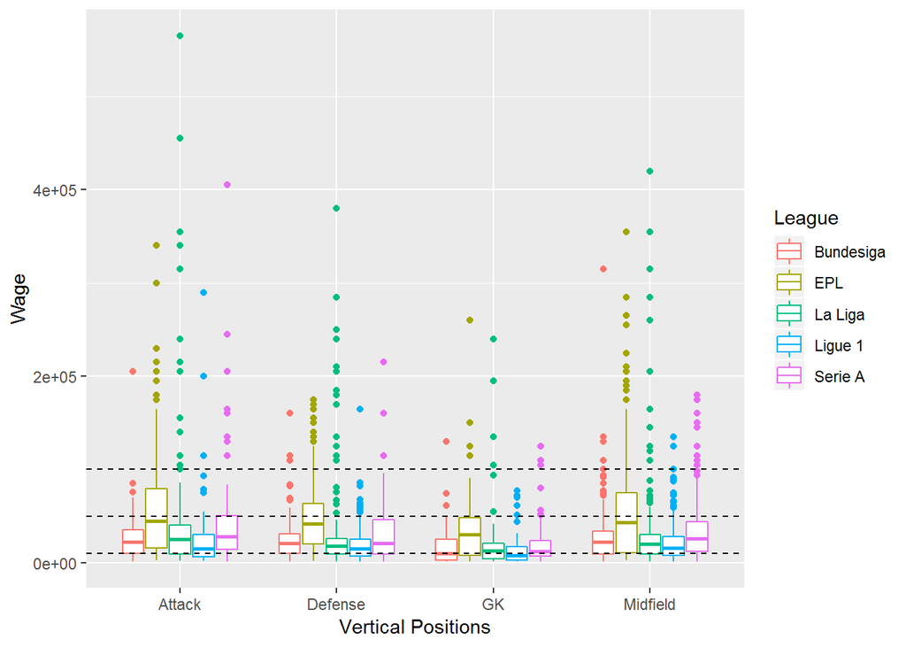

#### Section 3: Distributions of Wage, Overall, and Potential

**Questions to Explore:**

**Differences between top 5 leagues and the rest**

#### Partition dataset into top5 vs. rest

```
## [1] "There are  2840 playes in top 5 leagues."
```

```
## [1] "There are  15078 playes in the remaining leagues."
```

**Preliminary plots of densities**

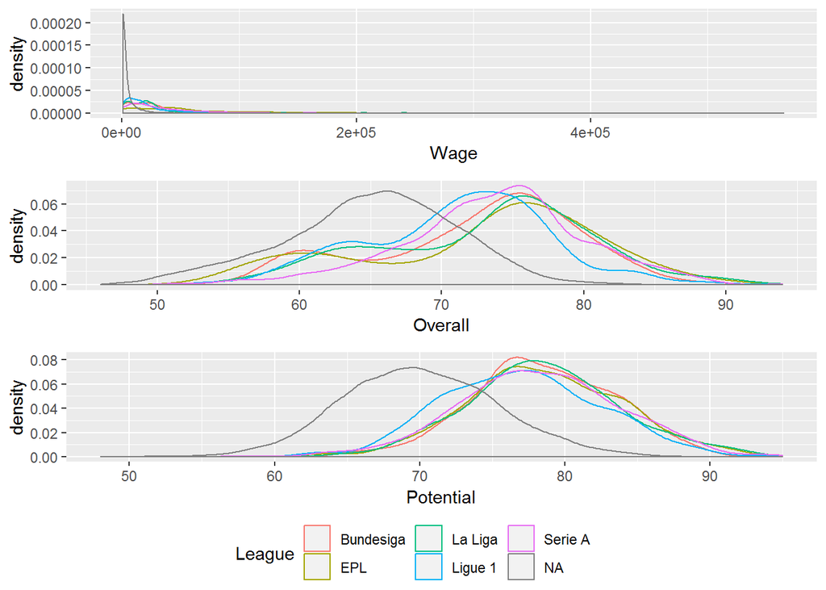

##### Remarks:

> ```
> As seen from the graph, there seems to be considerable diffferences between players from top 5 leagues and the rest. As such, I am looking further into the distributions among the top 5.
> ```

#### Further look into distribution of Wage, Overall, and Potential across top5 leagues

Densities of Wage, Overall, Potential among the top 5 leagues.

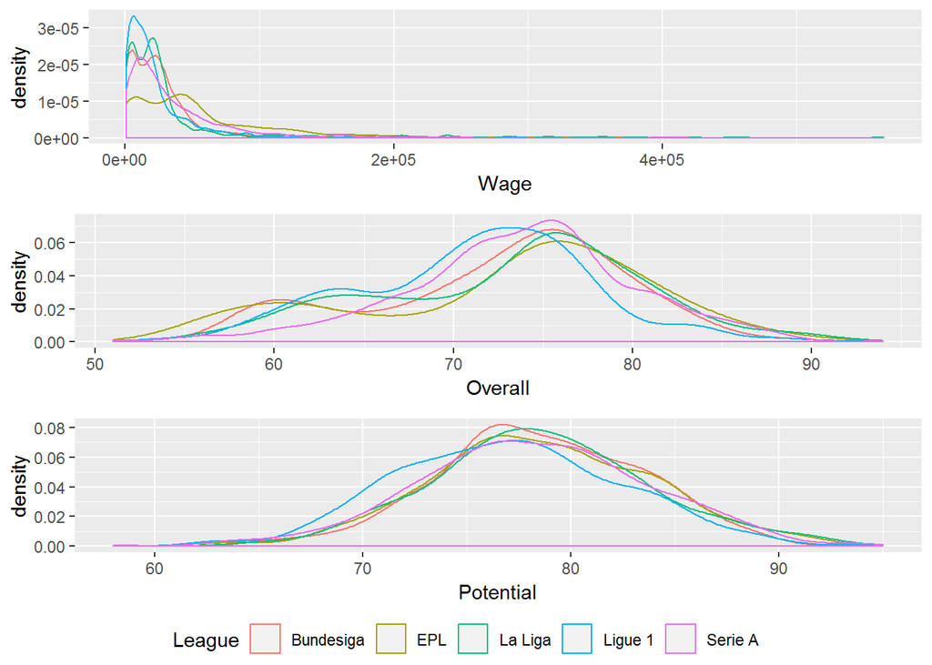

##### 3.1 | — Wage

Quantiles of Wage among top 5 leagues:

```
##      Bundesiga    EPL La Liga Ligue 1 Serie A
## 10%       3000   4000    3000    3000    4000
## 20%       5000   8000    6000    5000    8000
## 30%      10000  23000   10000    8000   12000
## 40%      16000  33600   16000   12000   16000
## 50%      20000  41000   19000   15000   22000
## 60%      25000  48000   22000   18000   29000
## 70%      29000  56000   26000   23000   40000
## 80%      36000  84200   32000   31000   53000
## 90%      48800 120000   63500   48000   76600
## 100%    315000 355000  565000  290000  405000
```

#### Is Average Wage in EPL higher than other leagues?

From the graph and table above, it appears that the average wage is higher in EPL than in other leagues. To verify, conduct the Hypothesis Test:

$$H_0: \mu_{E} = \mu_{O}$$
$$H_1: \mu_{E} > \mu_{O}$$
where $\mu_E$ is average wage in EPL, $\mu_O$ is average wage in other leagues.

From the dataset, we have:

| League | $\mu$ |  | $s$ |  | $n$ |
| --- | --- | --- | --- | --- | --- |
| EPL | $\mu_E$ | 52,813.95 | $s_E$ | 52,173.56 | 645 |
| Other | $\mu_O$ | 29,120.27 | $s_O$ | 41,807.51 | 2195 |

Test statistics, given sample variance, use the T-test:
$$t = \frac{\bar{x}_E - \bar{x}_O}{\sqrt{\frac{s_E^2}{n_E} + \frac{s_O^2}{n_O}}}$$

$$df = \frac{\Big[\frac{s_E^2}{n_E} + \frac{s_O^2}{n_O}\Big]^2}
{\bigg[\frac{(s_E^2/n_E)^2}{n_E - 1}\bigg] + \bigg[\frac{(s_O^2/n_O)^2}{n_O - 1}\bigg]
}$$

Given the data from top5:

```
## [1] "t-stat = 10.5786"
```

```
## [1] "degree of freedom = 637"
```

At $\alpha = .01$, degree of freedom = 637

```
## [1] "t_alpha = 2.3322"
```

Conclusion:
$$t = 10.5786 > t_{\alpha} = 2.3322 \implies \text{Reject } H_0$$
As such, at the $99\%$ confidence level, it appears that the Average Wage in EPL is higher than in other leagues.

#### Does this lead to higher Average Overall among EPL playes?

##### 3.2 | — Overall

Quantiles of Overall among top 5 leagues:

```
##      Bundesiga EPL La Liga Ligue 1 Serie A
## 10%         61  59      62      62      66
## 20%         66  64      66      65      69
## 30%         70  70      70      68      71
## 40%         72  73      73      70      72
## 50%         74  75      75      72      74
## 60%         75  76      76      73      75
## 70%         77  78      77      75      77
## 80%         79  80      79      76      78
## 90%         81  82      82      78      82
## 100%        90  91      94      92      94
```

Is Average Overall in EPL higher than other leagues?
$$H_0: \mu_{E} = \mu_{O}$$
$$H_1: \mu_{E} > \mu_{O}$$
where $\mu_E$ is average Overall in EPL, $\mu_O$ is average Overall in other leagues.

From the dataset, we have:

| League | $\mu$ |  | $s$ |  | $n$ |
| --- | --- | --- | --- | --- | --- |
| EPL | $\mu_E$ | 72.7597 | $s_E$ | 8.4440 | 645 |
| Other | $\mu_O$ | 72.6820 | $s_O$ | 7.0087 | 2195 |

Similarly, given sample variance, use the T-test:

```
## [1] "t-stat = 0.2131"
```

```
## [1] "degree of freedom = 636"
```

At $\alpha = .01$, degree of freedom = 636

```
## [1] "t_alpha = 2.3322"
```

Conclusion:
$$t = 0.2131 < t_{\alpha} = 2.3322 \implies \text{Fail to Reject } H_0$$

As such, at the $99\%$ confidence level, there does not appear to have reasons that the Average Overall in EPL is higher than that of other leagues.

#### What about Potential?

##### 3.3 | — Potential

Quantiles of Potential among top 5 leagues:

```
##      Bundesiga EPL La Liga Ligue 1 Serie A
## 10%         72  72      72      70      71
## 20%         75  74      74      72      74
## 30%         76  76      76      74      75
## 40%         77  77      77      75      77
## 50%         78  78      78      77      78
## 60%         80  80      80      78      80
## 70%         81  81      81      80      81
## 80%         83  83      83      82      83
## 90%         85  85      85      84      86
## 100%        90  93      94      95      94
```

Is Average Overall in EPL higher than other leagues?
$$H_0: \mu_{E} = \mu_{O}$$
$$H_1: \mu_{E} > \mu_{O}$$
where $\mu_E$ is average Potential in EPL, $\mu_O$ is average Potential in other leagues.

From the dataset, we have:

| League | $\mu$ |  | $s$ |  | $n$ |
| --- | --- | --- | --- | --- | --- |
| EPL | $\mu_E$ | 78.6264 | $s_E$ | 5.3305 | 645 |
| Other | $\mu_O$ | 78.1134 | $s_O$ | 5.2898 | 2195 |

Similarly, given sample variance, use the T-test:

```
## [1] "t-stat = 2.1521"
```

```
## [1] "degree of freedom = 629"
```

At $\alpha = .01$, degree of freedom = 629

```
## [1] "t_alpha = 2.3323"
```

Conclusion:
$$t = 2.1521 < t_{\alpha} = 2.3322 \implies \text{Fail to Reject } H_0$$

As such, at the $99\%$ confidence level, there does not appear to have reasons that the Average Potential in EPL is higher than that of other leagues either.

##### Remarks:

> ```
> At the 99% confidence level, it appears that while the Average Wage of players in EPL is higher than that of other leagues, the average player in EPL does not have higher Overall or Potential ratings.
> ```

#### Is the difference in Average Wage related to players’ Overall ratings?

#### Section 4: Difference between top 1 % and the rest

**Questions to consider:**

1. Among top 1% Overall ratings, is there difference in Average Wage between EPL and the rest?
2. What about the remaining 99%?

Partition among the top5 league players into top 1 % and the rest according to the Overall ratings:

```
## [1] "The 99% quantile Overall among players from top 5 leagues is 88"
```

As such, top5_01 consists of players whose Overall ratings are at least 88, and top5_99 of players whose ratings are below 88.

##### 4.1 | — Plots

**Among top 1%**

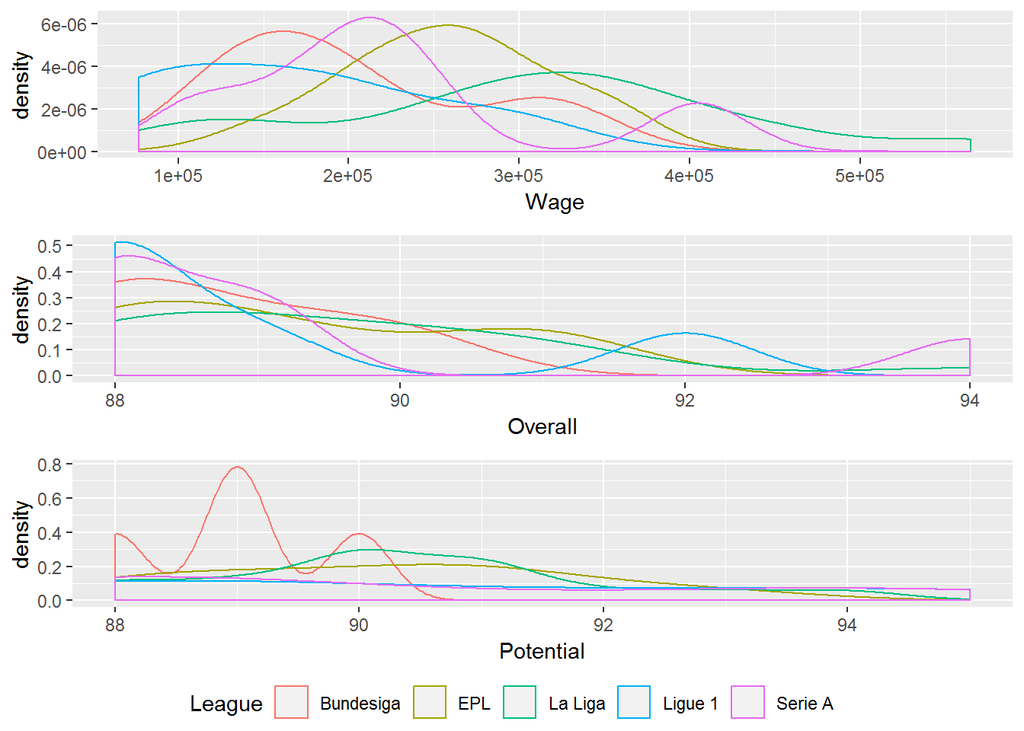

Surprisingly, among the top 1% of players, La Liga players appear to have higher Wage, and Serie A appears to have players with higher Overall and Potential ratings.

```
##
## Bundesiga       EPL   La Liga   Ligue 1   Serie A
##         4        11        16         5         6
```

**Among the other 99%**

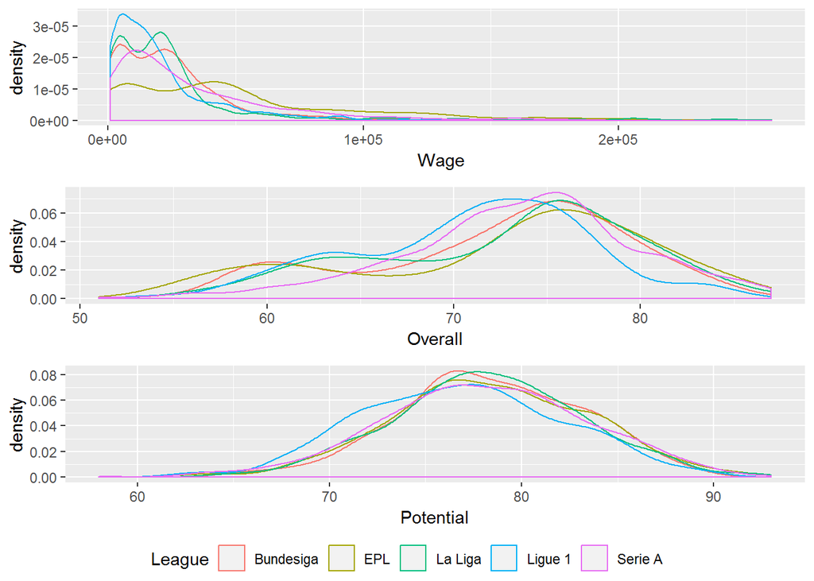

##### 4.2 | — Overall - Top 1%

Quantiles of Wage among the top 1% of players from top 5 leagues:

```
##      Bundesiga    EPL La Liga Ligue 1 Serie A
## 10%     139000 205000  135000   86200  137500
## 20%     148000 205000  240000   95400  165000
## 30%     157000 225000  262500  113000  185000
## 40%     169000 255000  285000  139000  205000
## 50%     182500 260000  315000  165000  210000
## 60%     196000 265000  340000  179000  215000
## 70%     216000 285000  355000  193000  230000
## 80%     249000 300000  380000  218000  245000
## 90%     282000 340000  437500  254000  325000
## 100%    315000 355000  565000  290000  405000
```

#### Is Average Wage in EPL higher than other leagues?

$$H_0: \mu_{E} = \mu_{O}$$
$$H_1: \mu_{E} > \mu_{O}$$
where $\mu_E$ is average wage in EPL, $\mu_O$ is average wage in other leagues.

From the dataset, we have:

| League | $\mu$ |  | $s$ |  | $n$ |
| --- | --- | --- | --- | --- | --- |
| EPL | $\mu_E$ | 258,636 | $s_E$ | 60,872.4 | 11 |
| Other | $\mu_O$ | 254,871 | $s_O$ | 119,048.9 | 31 |

Test statistics, given sample variance, use the T-test as above, and given the data from top5:

```
## [1] "t-stat = 0.1336"
```

```
## [1] "degree of freedom = 6"
```

At $\alpha = .01$, degree of freedom = 6

```
## [1] "t_alpha = 3.1427"
```

Conclusion:
$$t = 0.1336 < t_{\alpha} = 3.1427 \implies \text{Fail to Reject } H_0$$
As such, at the $99\%$ confidence level, it does not appear to have reasons that among the top 1% players, EPL players have higher Average Wage than the other 4 leagues.

#### However, is it those in La Liga who have Average Wage than other leagues?

From the graph above, it appears that among the top 1%, the average wage is higher in La Liga than in other leagues. To verify, conduct the Hypothesis Test:

$$H_0: \mu_{E} = \mu_{O}$$
$$H_1: \mu_{E} > \mu_{O}$$
where $\mu_E$ is average wage in La Liga, $\mu_O$ is average wage in other leagues.

From the dataset, we have:

| League | $\mu$ |  | $s$ |  | $n$ |
| --- | --- | --- | --- | --- | --- |
| La Liga | $\mu_E$ | 307,125 | $s_E$ | 123,037.6 | 16 |
| Other | $\mu_O$ | 224,308 | $s_O$ | 81,814.8 | 26 |

Test statistics, given sample variance, use the T-test as above, and given the data from top5:

```
## [1] "t-stat = 2.3872"
```

```
## [1] "degree of freedom = 14"
```

At $\alpha = .01$, degree of freedom = 14

```
## [1] "t_alpha = 2.6245"
```

Conclusion:
$$t = 2.3872 < t_{\alpha} = 2.6245 \implies \text{Fail to Reject } H_0$$
Similarly, at the $99\%$ confidence level, it does not appear to have reasons that among the top 1% players, La Liga players have higher Average Wage than the other 4 leagues.

##### 4.3 | — Overall - Remaining 99%

Quantiles of Wage among the remaining 99% of players from top 5 leagues:

```
##      Bundesiga    EPL La Liga Ligue 1 Serie A
## 10%       2800   4000    3000    3000    4000
## 20%       5000   8000    5000    5000    8000
## 30%      10000  21900   10000    8000   12000
## 40%      16000  33000   15000   11000   16000
## 50%      20000  40000   19000   14000   22000
## 60%      25000  46000   22000   18000   28000
## 70%      29000  55000   26000   22000   39000
## 80%      35400  80000   31000   31000   51400
## 90%      48000 115000   53000   47000   74000
## 100%    135000 230000  260000  135000  180000
```

#### Is Average Wage in EPL higher than other leagues?

From the graph and table above, it appears that the average wage is higher in EPL than in other leagues. To verify, conduct the Hypothesis Test:

$$H_0: \mu_{E} = \mu_{O}$$
$$H_1: \mu_{E} > \mu_{O}$$
where $\mu_E$ is average wage in EPL, $\mu_O$ is average wage in other leagues.

From the dataset, we have:

| League | $\mu$ |  | $s$ |  | $n$ |
| --- | --- | --- | --- | --- | --- |
| EPL | $\mu_E$ | 49,243 | $s_E$ | 44,293.45 | 634 |
| Other | $\mu_O$ | 25,886 | $s_O$ | 28,904.69 | 2164 |

Test statistics, given sample variance, use the T-test as above, from given the data from top5:

```
## [1] "t-stat = 12.5194"
```

```
## [1] "degree of freedom = 630"
```

At $\alpha = .01$, degree of freedom = 630

```
## [1] "t_alpha = 2.3323"
```

Conclusion:
$$t = 12.5194 > t_{\alpha} = 2.3323 \implies \text{Reject } H_0$$
As such, at the $99\%$ confidence level, there appears strong evidence that among the remaining 99% players, the Average Wage in EPL is higher than that of other leagues.

##### Concluding remarks

As seen from the above exploratory plots and hypothesis tests, there appears strong reasons to support the hypothesis that: